# Coursework Report

*N* removed NAs: 2

*N* removed typo: 1

*N* removed <18: 19

*N* total clean: 128

| Group | *N* | *M*<sub>age</sub> | *M*<sub>rating</sub> |
| --- | --- | --- | --- |
| Control | 63 | 20.52 | 5.69 |
| Experim | 65 | 20.75 | 6.67 |

**Main analysis results**

*t*(126) = -7.37, *p* < .001

[interactive chart not shown]

[figure not shown]

[interactive chart not shown]

# Coursework Report

Analysing Data, Spring 2020

# Methods

## Participants

The initial number of participants was 150 famale participants. However, 19 participants were removed due to unethical ages and 3 were removed due to missing ages. This left the results with 128 participants who were used in this study. The age of participants ranged from 18 years old to 27 with a standard deviation of 1.84 See figure 1 for descriptives by condition.

Figure 1: *Age descriptive of Participants by Condition*

| Condition | N | Mean Age | <sub>SD</sub> | Minimum Age | Maximum Age |
| --- | --- | --- | --- | --- | --- |
| Control | 63 | 20.52 | 1.63 | 18 | 25 |
| Experimental | 65 | 20.75 | 2.03 | 18 | 27 |

## Design

In this study were trying to examine whether colour influences attractiveness. Based on existing literature we hypothesised that when a photo of a man will be associated with the colour red he will be perceived as more attractive. More specifically, that a man on a red background would receive a higher mean attractiveness rating compared to a man on a white background.

As this is a replication study, we used the exact same method as Elliot at al. (2010).

The participants viewed a black-and-white photo of a man on a red (*n* = 65) or white (*n* = 63) background for 5 seconds. Once the viewing was over, they were asked to report on the man’s *perceived attractiveness* using a 9-point scale. The photo was 4 inches x 6 inches big including the man’s head and upper torso. He was a young Caucasian man, mooderately attractive, with brown hair, wearing a button-up shirt. The photo was centred on an 8.5 inch X 11 inch page with colour surrounding the photo of the man.

The parameters of the red colour were LCh(49.6, 58.8, 30.4). White was operationalized as the absence of additional color in the background.

## Measure

*Percieved Attractiveness* was rated using the same items as the original study (Elliot et al., 2010). Three face-valid items were used:

**Item 1** “How attractive do you think this person is?”

**Item 2** “How pleasant is this person to look at?”

**Item 3** “If I were to meet this person in the picture face to face, I would think he is attractive”

The ratings for these items were given on a 9-point Likert scale. 1 meaning *‘not attractive at all’* and 9 meaning *‘extremely attractive’*.

The collected results were analysed by comparing a composite mean score for each condition and carrying out t-tests, and testing for a p-value of *p*<.05.

# Results

We investigated whether, as hypothesised, the men who were viewed in conjunction with the colour red were perceived as more attractive.To understand this, we compared the composite means on the two conditions using an independent-measures *t*-test.

The results showed that the means of the two conditions were consistently different across all three items. The average ratings of the experimental condition were about 1 rating point higher on each item (*M*<sub>diff</sub> = 0.98) . This is interesting as both conditions were looking at a photo of the same man, the only diffrence being the color of the frame. See figure 2 for comparisons of the mean rating for each item.

Figure 2: *Mean Score of Each Item by Condtion*

| Condition | *N* | *Mean* Item 1 | <sub>SD</sub> | *Mean* Item 2 | <sub>SD</sub> | *Mean* Item 3 | <sub>SD</sub> |
| --- | --- | --- | --- | --- | --- | --- | --- |
| Control | 63 | 5.62 | 1.41 | 5.62 | 1.28 | 5.83 | 1.25 |
| Experimental | 65 | 6.60 | 1.53 | 6.69 | 1.33 | 6.72 | 1.26 |

Presented below is a graph to further visualise the differences between the two conditions.

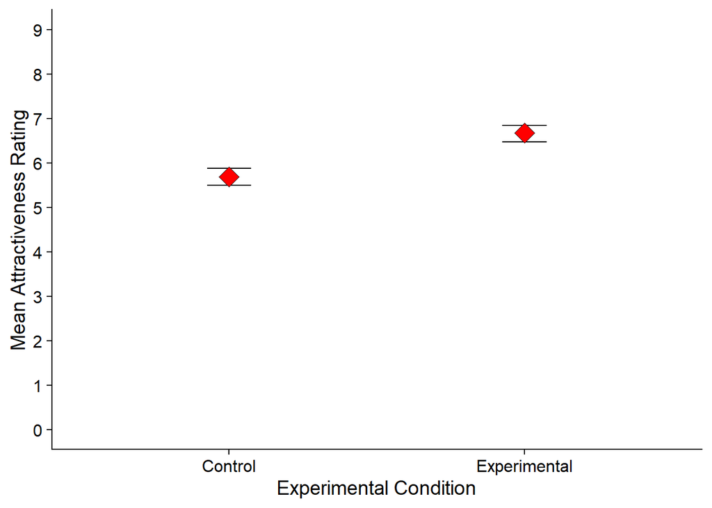

Overall, there was a significant difference in the mean ratings for the red versus the white conditions *M*<sub>diff</sub> = 0.98, 95% CI [-1.25, -0.72] , *p* = <.001. This means that our hypothesis was supported by our data and the man was rated more attractively on a red background.

# Discussion

Just the same as the original study, our research provides strong experimental evidence for the notion that men are more attractive in conjunction with the colour red. We recreated ‘Experiment 1’ from (Elliot et al., 2010) which originally used a total of 21 female participants while our research tested over 100 participants, demonstrating that the same phenomenon can be observed on a larger pool of participants and in a different country. This indicates that the original results are unlikely to be due to individual differences and are due to the actual mechanism at hand.

What our study could have done, or future research could do, differently is test the phenomena on a wider scope. Future research could add more photos of men of similar attractiveness, to investigate if all the men will score higher attractiveness ratings in a red frame compared to a white frame. Alternatively, more colours could be added to see if other colours such as blue, green or yellow have any consistent and/or significant effects. Furthermore, more research could be carried out into these effects across different cultures, much as the original study. Alternatively, the phenomenon could be examined in the opposite direction; are women more attractive to men in conjunction with the colour red (Lin, 2014)? Are homosexual men/women more attracted to same sex individuals in conjunction with the colour red? All of these individuals make up the general population and it might be fruitful investigating whether red enhancing attractiveness is an effect that remains across genders and sexuality. Lastly, our study used an independent measures design which arguably is more susceptible to individual differences. Future research could try to utilize repeated measures instead, whereby women rate men of similar attractiveness (CFD | Chicago Face Database, 2015) on different coloured backgrounds to investigate the effects of red.

Previously, research has identified many things that make men attractive; a symmetrical and chiselled face, with a sharp jawline; a proportional, muscular, and relatively tall body; his kindness, charisma, and intelligence (Buss & Shackelford, 2008; Gangestad & Scheyd, 2005; Rhodes & Zebrowitz, 2002) have all been shown to all play a role. However, once again, colour has shown to play a role as a novel determinant in a man’s attractiveness.

Even so, is it the colour red that makes men inherently more attractive or does the colour red have other effects that in turn make the men seem more attractive? For example, there is evidence to support that men wearing red football jerseys play more aggressively and win more games (Attrill et al., 2008). Hence, it might be that red has to do with a man’s self-perception, making him act more confidently, and as a result reaping more success during his date or business presentation. Alternatively, it might be the case that red symbolizes power and status, as opposed to changing how men behave. Would a man with a red car/suit/ be perceived as more dominant and therefore more attractive, as opposed to a men with a white car/suit?

In the past, colour has often been associated with a purely aesthetic value. However, this study, as well as others, may prove that colours have more meaning or psychological effects than we might realize. For example, if a sorrowful-looking older lady dressed in all black accidently cuts in front of someone in a queue, that person may be less prone to lash out at her, as opposed to if it was a baggy-jeaned teenager. Whether consciously, or sub-consciously, to observant individuals, the colour black, coupled with her facial expression, and age, would signal grief, perhaps the loss of a husband. A woman going clubbing alone might be weary to wear her short red dress, as opposed to the short green one, in order not to seem too sexually inviting. There is definitely promising and yet undiscovered research in colour that will yield many insightful and provocative thoughts in the years to come.

# References

Attrill, M. J., Gresty, K. A., Hill, R. A., & Barton, R. A. (2008). Red shirt colour is associated with long-term team success in English football. *Journal of Sports Sciences, 26(6)*, 577–582. https://doi.org/10.1080/02640410701736244

Buss, D. M., & Shackelford, T. K. (2008). Attractive Women Want it All: Good Genes, Economic Investment, Parenting Proclivities, and Emotional Commitment. *Evolutionary Psychology, 6(1)*, 147470490800600. https://doi.org/10.1177/147470490800600116

CFD | *Chicago Face Database.* (2015). https://chicagofaces.org/default/

Elliot, A. J., Niesta Kayser, D., Greitemeyer, T., Lichtenfeld, S., Gramzow, R. H., Maier, M. A., & Liu, H. (2010). Red, rank, and romance in women viewing men. *Journal of Experimental Psychology: General,* 139(3), 399–417. https://doi.org/10.1037/a0019689

Gangestad, S. W., & Scheyd, G. J. (2005). The Evolution of Human Physical Attractiveness. *Annual Review of Anthropology,* 34(1), 523–548. https://doi.org/10.1146/annurev.anthro.33.070203.143733

Lin, H. (2014). Red-colored products enhance the attractiveness of women. *Displays, 35(4)*, 202–205. https://doi.org/10.1016/j.displa.2014.05.009

Rhodes, G., & Zebrowitz, L. A. (Eds.). (2002). Facial attractiveness: *Evolutionary, cognitive, and social perspectives. Ablex*. https://research-repository.uwa.edu.au/en/publications/facial-attractiveness-evolutionary-cognitive-and-social-perspecti